# Machine learning for the smart building with Python, Scikit-learn and statsmodel

## Data loading and pre-processing

### Load the Python modules connected_building

```python
# Load of the modules connected_building and connected_sensor (Gilles Morel - UTC)
from connected_building import *
```

### Load the database of the sensors of the Meudon smart building

- Object "connected_building" is referenced by variable CB
- Display of the rooms (of the Meudon building) selected for the study and their list of sensors

```python
load_Meudon()
from connected_building import *
print(CB)
for room in CB.get_rooms().values() :
    room.print_sensors()
```

```
Connecting to the PostgreSQL database...
Reading the sensors description in the sensor SQL table
Number of sensors read : 1877
Database connection closed.
Building : 'Meudon' - Rooms : ['Bureau 2 - Niv. 1 Bat A', 'Bureau 1 - Niv. 1 Bat A', 'Salle de réunion 1', 'Salle de réunion 2'])
Building : 'Meudon' - Rooms : ['Bureau 2 - Niv. 1 Bat A', 'Bureau 1 - Niv. 1 Bat A', 'Salle de réunion 1', 'Salle de réunion 2'])
Sensors of the room Bureau 2 - Niv. 1 Bat A :
Sensor n° 104, 'Nombre de Fenetres Ouvertes Bureau 2 - Niv. 1 Bat A', type : 'Moyenne', unit  : 'Unité'
Sensor n° 111, 'Reglage Luminaire 1er Jour Bureau 2 - Niv. 1 Bat A', type : 'Moyenne', unit  : '%'
Sensor n° 112, 'Reglage Luminaire 2nd Jour Bureau 2 - Niv. 1 Bat A', type : 'Moyenne', unit  : '%'
Sensor n° 113, 'Reglage Vannes Bureau 2 - Niv. 1 Bat A', type : 'Moyenne', unit  : '%'
Sensor n° 114, 'Reglage OVM Bureau 2 - Niv. 1 Bat A', type : 'Moyenne', unit  : '%'
Sensor n° 115, 'Reglage Brasseurs Bureau 2 - Niv. 1 Bat A', type : 'Moyenne', unit  : '%'
Sensor n° 116, 'Decalage Consigne Temp. Bureau 2 - Niv. 1 Bat A', type : 'Moyenne', unit  : '%'
Sensor n° 119, 'Moyenne Reglage stores Bureau 2 - Niv. 1 Bat A', type : 'Moyenne', unit  : None
Sensor n° 120, 'Detection de Presence Bureau 2 - Niv. 1 Bat A', type : 'Moyenne', unit  : None
Sensor n° 123, 'Tenperature Ambiante Bureau 2 - Niv. 1 Bat A', type : 'Moyenne', unit  : '°C'
Sensor n° 124, 'Temperature de Dalle Bureau 2 - Niv. 1 Bat A', type : 'Moyenne', unit  : '°C'
Sensors of the room Bureau 1 - Niv. 1 Bat A :
Sensor n° 103, 'Nombre de Fenetres Ouvertes Bureau 1 - Niv. 1 Bat A', type : 'Moyenne', unit  : 'Unité'
Sensor n° 105, 'Reglage Luminaire 1er Jour Bureau 1 - Niv. 1 Bat A', type : 'Moyenne', unit  : '%'
Sensor n° 106, 'Reglage Luminaire 2nd Jour Bureau 1 - Niv. 1 Bat A', type : 'Moyenne', unit  : '%'
Sensor n° 107, 'Reglage Vannes Bureau 1 - Niv. 1 Bat A', type : 'Moyenne', unit  : '%'
Sensor n° 108, 'Reglage OVM Bureau 1 - Niv. 1 Bat A', type : 'Moyenne', unit  : '%'
Sensor n° 109, 'Reglage Brasseurs Bureau 1 - Niv. 1 Bat A', type : 'Moyenne', unit  : '%'
Sensor n° 110, 'Decalage Consigne Temp. Bureau 1 - Niv. 1 Bat A', type : 'Moyenne', unit  : '%'
Sensor n° 117, 'Moyenne Reglage stores Bureau 1 - Niv. 1 Bat A', type : 'Moyenne', unit  : None
Sensor n° 118, 'Detection de Presence Bureau 1 - Niv. 1 Bat A', type : 'Moyenne', unit  : None
Sensor n° 121, 'Tenperature Ambiante Bureau 1 - Niv. 1 Bat A', type : 'Moyenne', unit  : '°C'
Sensor n° 122, 'Temperature de Dalle Bureau 1 - Niv. 1 Bat A', type : 'Moyenne', unit  : '°C'
Sensors of the room Salle de réunion 1 :
Sensor n° 187, 'Salle de Réunion 1 - Mesure CO2 - Niv.2 Bat A', type : 'Moyenne', unit  : 'ppm'
Sensor n° 188, "Salle de Reunion 1 - Detection d'Occupation - Niv. 2 Bat A", type : 'Moyenne', unit  : None
Sensors of the room Salle de réunion 2 :
Sensor n° 189, 'Salle de Réunion 2 - Mesure CO2 - Niv.2 Bat A', type : 'Moyenne', unit  : 'ppm'
Sensor n° 190, "Salle de Reunion 2 - Detection d'Occupation - Niv. 2 Bat A", type : 'Moyenne', unit  : None
```

### Reading two months of data (1 data each 15 mn) in the data table of Meudon sensors (a subset of interesting rooms and sensors have being previously selected among the 2000 sensors existing in the database in order to limit time series downloaded)

```python
# Time series data of January and February 2017 are loaded (last date is excluded in Python)
CB.read_data_DB('2017-01-01', '2017-03-01')
```

```
Loading the data of the sensors of the room  Bureau 2 - Niv. 1 Bat A
Reading the data (time serie) of the sensor n°  104
SQL data read : 5661
Reading the data (time serie) of the sensor n°  111
SQL data read : 5661
Reading the data (time serie) of the sensor n°  112
SQL data read : 5661
Reading the data (time serie) of the sensor n°  113
SQL data read : 5661
Reading the data (time serie) of the sensor n°  114
SQL data read : 5661
Reading the data (time serie) of the sensor n°  115
SQL data read : 5661
Reading the data (time serie) of the sensor n°  116
SQL data read : 5661
Reading the data (time serie) of the sensor n°  119
SQL data read : 5661
Reading the data (time serie) of the sensor n°  120
SQL data read : 5661
Reading the data (time serie) of the sensor n°  123
SQL data read : 5661
Reading the data (time serie) of the sensor n°  124
SQL data read : 5661
Loading the data of the sensors of the room  Bureau 1 - Niv. 1 Bat A
Reading the data (time serie) of the sensor n°  103
SQL data read : 5661
Reading the data (time serie) of the sensor n°  105
SQL data read : 5661
Reading the data (time serie) of the sensor n°  106
SQL data read : 5661
Reading the data (time serie) of the sensor n°  107
SQL data read : 5661
Reading the data (time serie) of the sensor n°  108
SQL data read : 5661
Reading the data (time serie) of the sensor n°  109
SQL data read : 5661
Reading the data (time serie) of the sensor n°  110
SQL data read : 5661
Reading the data (time serie) of the sensor n°  117
SQL data read : 5661
Reading the data (time serie) of the sensor n°  118
SQL data read : 5661
Reading the data (time serie) of the sensor n°  121
SQL data read : 5661
Reading the data (time serie) of the sensor n°  122
SQL data read : 5661
Loading the data of the sensors of the room  Salle de réunion 1
Reading the data (time serie) of the sensor n°  187
SQL data read : 5661
Reading the data (time serie) of the sensor n°  188
SQL data read : 5661
Loading the data of the sensors of the room  Salle de réunion 2
Reading the data (time serie) of the sensor n°  189
SQL data read : 5661
Reading the data (time serie) of the sensor n°  190
SQL data read : 5661
```

### Get some sensors objects from the rooms "Bureau 1" and "Bureau 2" (offices) and store them in variable for next steps

```python
B1 = CB.get_room('Bureau 1 - Niv. 1 Bat A')
# sensor of ambiant temperature
s121 = B1.get_sensors()[121]
# temperature of the heating floor
s122 = B1.get_sensors()[122]

B2 = CB.get_room('Bureau 2 - Niv. 1 Bat A')
# sensor of ambiant temperature
s123 = B2.get_sensors()[123]
```

### Some preliminary data checking and visualisation (before tackling the classification)

#### Display the data (time serie) of the ambiant temperature sensor 121 for the whole period (call a method "plot" defined on the class sensor)

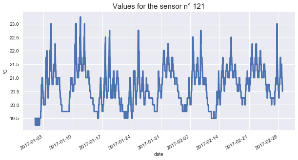

```python
s121.plot()
```

#### Main statistics on the sensor

```python
s121.stats()
```

```
Sensor n° 121, 'Tenperature Ambiante Bureau 1 - Niv. 1 Bat A', type : 'Moyenne', unit  : '°C'
Période du  2017-01-01  au  2017-03-01
Number of valid data :  5661
Timestep :  0 days 00:15:00
Mean value : 20.67 °C
Min(date min) :  19.25 °C  on  2017-01-01 00:45:00+01:00
Max(date max) :  23.25 °C  on  2017-01-11 19:00:00+01:00
Standard deviation : 0.71 °C
```

#### Checking missing data for the whole 2 months time serieperiod (check day by day)

```python
s121.check_missing_data_by_day(printed=True)
```

```
Sensor n° 121 :
No missing data for the day 2017-01-01
No missing data for the day 2017-01-02
No missing data for the day 2017-01-03
No missing data for the day 2017-01-04
No missing data for the day 2017-01-05
No missing data for the day 2017-01-06
No missing data for the day 2017-01-07
No missing data for the day 2017-01-08
No missing data for the day 2017-01-09
No missing data for the day 2017-01-10
No missing data for the day 2017-01-11
No missing data for the day 2017-01-12
Hours of missing data for the day : 2017-01-13 - Friday
11:45:00
12:00:00
13:15:00
13:30:00
No missing data for the day 2017-01-14
No missing data for the day 2017-01-15
No missing data for the day 2017-01-16
No missing data for the day 2017-01-17
No missing data for the day 2017-01-18
No missing data for the day 2017-01-19
No missing data for the day 2017-01-20
No missing data for the day 2017-01-21
No missing data for the day 2017-01-22
No missing data for the day 2017-01-23
No missing data for the day 2017-01-24
No missing data for the day 2017-01-25
No missing data for the day 2017-01-26
No missing data for the day 2017-01-27
No missing data for the day 2017-01-28
No missing data for the day 2017-01-29
No missing data for the day 2017-01-30
No missing data for the day 2017-01-31
No missing data for the day 2017-02-01
No missing data for the day 2017-02-02
No missing data for the day 2017-02-03
No missing data for the day 2017-02-04
```

[output cut: 9 more lines]

```
No missing data for the day 2017-02-14
No missing data for the day 2017-02-15
No missing data for the day 2017-02-16
No missing data for the day 2017-02-17
No missing data for the day 2017-02-18
No missing data for the day 2017-02-19
No missing data for the day 2017-02-20
No missing data for the day 2017-02-21
No missing data for the day 2017-02-22
No missing data for the day 2017-02-23
No missing data for the day 2017-02-24
No missing data for the day 2017-02-25
No missing data for the day 2017-02-26
No missing data for the day 2017-02-27
No missing data for the day 2017-02-28
```

```
{'2017-01-13': Index([11:45:00, 12:00:00, 13:15:00, 13:30:00], dtype='object', name='date')}
```

#### Display the four ohlc values by day (open, high, low, close)

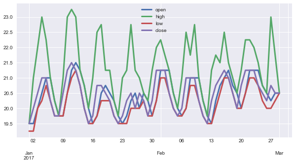

```python
s121.plot_four_values_by_day()
```

#### Display of the daily time series for the first week of January (7 first days of the whole 2 months serie)

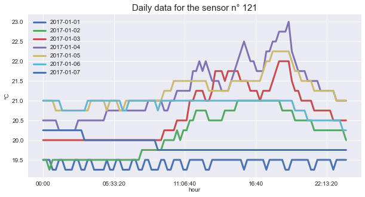

```python
s121.plot_ndays_by_range('2017-01-01', '2017-01-07')
```

#### Display of an average day of the week (left) and an average day of WE (right)

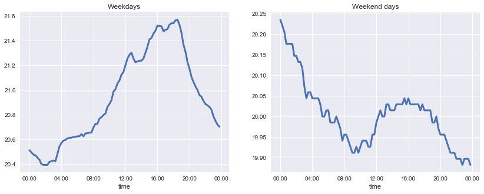

```python
s121.plot_dayofweek_vs_WE()
```

#### Display of two TS (121 and 123) on the same day

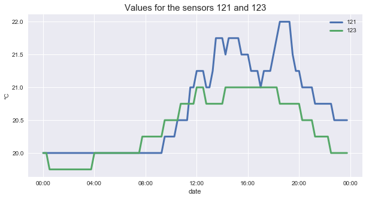

```python
s121.plot_compare(s123, day='2017-01-03')
```

## A - Classification with Scikit-learn ML tools

### Use case A.1 : guess the day of the week of a daily temperature sensor data time series

### Detailed explanation : starting from a long sequence of an ambiant tempature sensor data of an office (ex : 2 months, 1 data each 15 mn), we first extract daily sequences and then a set of statistic features for each day (X input), which are each associated to the day of the week (y ouput). Classification models (different are tested and compared) are trained to match the week of the day (Sunday, Monday ....) to the daily data (either the temperature curve or the stats features) and then we try to guess the day of the week for new samples and evaluate the performance of different classification model in this case. By comparing prediction with real data day by day, we can try to understand which days are more easy to "recognise" (ex : no heating on Sunday) and try to improve the "feature" more adequat to characterise a day of temperature measurement

Suggestion for improvement : correlate the single temperature data with features from other device (ex : heating)

#### Load of the Scikit-Learn modules for classification and test

```python
# Different alternative models for classification
# SVC support vector classification
from sklearn.svm import LinearSVC
# k nearest neighbors classification
from sklearn.neighbors import KNeighborsClassifier
# Logistic regression (classification)
from sklearn.linear_model import LogisticRegression

# Modules for data pre-processing - Feature selection, scaling ...
from sklearn.feature_selection import SelectFromModel, SelectKBest, chi2
from sklearn import preprocessing
from sklearn.preprocessing import StandardScaler

# Modules for model scoring
from sklearn.metrics import accuracy_score, confusion_matrix, classification_report
# Modules for data set preparation and model optimisation
from sklearn.model_selection import cross_val_score, train_test_split, GridSearchCV

# Module for pipeline models
from sklearn.pipeline import Pipeline
```

#### The classification sequence following standard Scikit-Learn steps

##### Step 1 : Features extraction and preparation

##### Step 1a : building the X input matrix of features : one line corresponds to one sample (one day of data) : we replace the daily time series by four statistical value ohlc (open, high, low, close) - So the X columns correspond to these 4 features and the index are the days date

```python
X = s121.four_values_by_day()
print(X)
# Number of samples (X lines) and number of features (dimension - columns)
print(X.shape)
```

```
             open   high    low  close
2017-01-01  19.50  19.50  19.25  19.50
2017-01-02  19.50  21.00  19.25  20.00
2017-01-03  20.00  22.00  20.00  20.50
2017-01-04  20.50  23.00  20.25  21.00
2017-01-05  21.00  22.25  20.75  21.00
2017-01-06  21.00  21.00  20.25  20.25
2017-01-07  20.25  20.25  19.75  19.75
2017-01-08  19.75  19.75  19.75  19.75
2017-01-09  19.75  21.00  19.75  20.50
2017-01-10  20.50  23.00  20.50  21.25
2017-01-11  21.25  23.25  21.00  21.50
2017-01-12  21.50  23.00  21.25  21.25
2017-01-13  21.25  21.25  20.75  20.75
2017-01-14  20.75  20.75  20.00  20.00
2017-01-15  20.00  20.00  19.50  19.50
2017-01-16  19.50  21.00  19.50  19.75
2017-01-17  19.75  22.50  19.75  20.75
2017-01-18  20.50  22.75  20.25  20.75
2017-01-19  20.75  21.25  20.25  20.50
2017-01-20  20.50  21.25  20.25  20.25
2017-01-21  20.25  20.25  19.75  19.75
2017-01-22  19.75  19.75  19.50  19.50
2017-01-23  19.50  21.00  19.50  19.75
2017-01-24  19.75  21.25  19.50  20.25
2017-01-25  20.25  22.75  20.00  20.50
2017-01-26  20.50  21.25  20.00  20.00
2017-01-27  20.00  21.00  20.00  20.50
2017-01-28  20.50  20.50  20.25  20.25
2017-01-29  20.25  20.25  19.75  19.75
2017-01-30  19.75  21.25  19.75  20.25
2017-01-31  20.25  22.00  20.25  21.25
2017-02-01  21.25  22.25  21.00  21.25
2017-02-02  21.25  21.75  21.00  21.25
2017-02-03  21.25  21.25  20.50  20.50
2017-02-04  20.50  20.50  20.00  20.00
2017-02-05  20.00  20.00  19.75  19.75
2017-02-06  19.75  21.00  19.75  20.00
2017-02-07  20.00  22.50  20.00  21.00
2017-02-08  21.00  21.75  20.75  21.00
2017-02-09  21.00  22.75  20.75  21.00
2017-02-10  21.00  21.00  20.25  20.25
2017-02-11  20.25  20.25  19.75  19.75
2017-02-12  19.75  19.75  19.50  19.50
2017-02-13  19.50  21.25  19.50  20.25
2017-02-14  20.25  21.75  20.00  20.75
2017-02-15  20.75  21.50  20.50  21.00
2017-02-16  21.00  22.50  21.00  21.25
2017-02-17  21.25  21.50  21.00  21.00
2017-02-18  20.75  21.00  20.50  20.50
2017-02-19  20.50  20.50  20.00  20.00
2017-02-20  20.00  21.25  20.00  20.75
2017-02-21  20.50  22.25  20.50  21.25
2017-02-22  21.25  22.25  21.00  21.25
2017-02-23  21.25  22.00  21.00  21.25
2017-02-24  21.25  21.50  20.75  20.75
2017-02-25  20.75  20.75  20.25  20.50
2017-02-26  20.50  20.50  20.00  20.25
2017-02-27  20.25  23.00  20.00  20.75
2017-02-28  20.50  21.75  20.25  20.50
2017-03-01  20.50  20.50  20.50  20.50
(60, 4)
```

##### Step 1a-bis : scaling the X input data : the model is better (in classification) when the numerical input are "scaled" (mean = 0, var=1)

```python
# We use a special class for that
scaler = StandardScaler()
X_scaled = scaler.fit_transform(X)
print(X_scaled)
```

```
[[-1.65386858 -1.94680026 -1.8132963  -1.7323083 ]
 [-1.65386858 -0.37539198 -1.8132963  -0.83628677]
 [-0.76786756  0.67221354 -0.32969024  0.05973477]
 [ 0.11813347  1.71981906  0.16484512  0.95575631]
 [ 1.0041345   0.93411492  1.15391583  0.95575631]
 [ 1.0041345  -0.37539198  0.16484512 -0.388276  ]
 [-0.32486704 -1.16109612 -0.82422559 -1.28429754]
 [-1.21086807 -1.68489888 -0.82422559 -1.28429754]
 [-1.21086807 -0.37539198 -0.82422559  0.05973477]
 [ 0.11813347  1.71981906  0.65938047  1.40376707]
 [ 1.44713501  1.98172044  1.64845118  1.85177784]
 [ 1.89013552  1.71981906  2.14298654  1.40376707]
 [ 1.44713501 -0.1134906   1.15391583  0.50774554]
 [ 0.56113398 -0.63729336 -0.32969024 -0.83628677]
 [-0.76786756 -1.4229975  -1.31876095 -1.7323083 ]
 [-1.65386858 -0.37539198 -1.31876095 -1.28429754]
 [-1.21086807  1.1960163  -0.82422559  0.50774554]
 [ 0.11813347  1.45791768  0.16484512  0.50774554]
 [ 0.56113398 -0.1134906   0.16484512  0.05973477]
 [ 0.11813347 -0.1134906   0.16484512 -0.388276  ]
 [-0.32486704 -1.16109612 -0.82422559 -1.28429754]
 [-1.21086807 -1.68489888 -1.31876095 -1.7323083 ]
 [-1.65386858 -0.37539198 -1.31876095 -1.28429754]
 [-1.21086807 -0.1134906  -1.31876095 -0.388276  ]
 [-0.32486704  1.45791768 -0.32969024  0.05973477]
 [ 0.11813347 -0.1134906  -0.32969024 -0.83628677]
 [-0.76786756 -0.37539198 -0.32969024  0.05973477]
 [ 0.11813347 -0.89919474  0.16484512 -0.388276  ]
 [-0.32486704 -1.16109612 -0.82422559 -1.28429754]
 [-1.21086807 -0.1134906  -0.82422559 -0.388276  ]
 [-0.32486704  0.67221354  0.16484512  1.40376707]
 [ 1.44713501  0.93411492  1.64845118  1.40376707]
 [ 1.44713501  0.41031216  1.64845118  1.40376707]
 [ 1.44713501 -0.1134906   0.65938047  0.05973477]
 [ 0.11813347 -0.89919474 -0.32969024 -0.83628677]
 [-0.76786756 -1.4229975  -0.82422559 -1.28429754]
 [-1.21086807 -0.37539198 -0.82422559 -0.83628677]
 [-0.76786756  1.1960163  -0.32969024  0.95575631]
 [ 1.0041345   0.41031216  1.15391583  0.95575631]
 [ 1.0041345   1.45791768  1.15391583  0.95575631]
 [ 1.0041345  -0.37539198  0.16484512 -0.388276  ]
 [-0.32486704 -1.16109612 -0.82422559 -1.28429754]
 [-1.21086807 -1.68489888 -1.31876095 -1.7323083 ]
 [-1.65386858 -0.1134906  -1.31876095 -0.388276  ]
 [-0.32486704  0.41031216 -0.32969024  0.50774554]
 [ 0.56113398  0.14841078  0.65938047  0.95575631]
 [ 1.0041345   1.1960163   1.64845118  1.40376707]
 [ 1.44713501  0.14841078  1.64845118  0.95575631]
 [ 0.56113398 -0.37539198  0.65938047  0.05973477]
 [ 0.11813347 -0.89919474 -0.32969024 -0.83628677]
 [-0.76786756 -0.1134906  -0.32969024  0.50774554]
 [ 0.11813347  0.93411492  0.65938047  1.40376707]
 [ 1.44713501  0.93411492  1.64845118  1.40376707]
 [ 1.44713501  0.67221354  1.64845118  1.40376707]
 [ 1.44713501  0.14841078  1.15391583  0.50774554]
 [ 0.56113398 -0.63729336  0.16484512  0.05973477]
 [ 0.11813347 -0.89919474 -0.32969024 -0.388276  ]
 [-0.32486704  1.71981906 -0.32969024  0.50774554]
 [ 0.11813347  0.41031216  0.16484512  0.05973477]
 [ 0.11813347 -0.89919474  0.65938047  0.05973477]]
```

##### Step 1b : building the y output vector (labels) : this is the vector (column) of the real day names corresponding to the input 2 months days index - The method "period_day_name" transforms de vector of day-date to day-name (keeping the same order)

```python
y_name = s121.period_day_names()
print(y_name)
```

```
2017-01-01       Sunday
2017-01-02       Monday
2017-01-03      Tuesday
2017-01-04    Wednesday
2017-01-05     Thursday
2017-01-06       Friday
2017-01-07     Saturday
2017-01-08       Sunday
2017-01-09       Monday
2017-01-10      Tuesday
2017-01-11    Wednesday
2017-01-12     Thursday
2017-01-13       Friday
2017-01-14     Saturday
2017-01-15       Sunday
2017-01-16       Monday
2017-01-17      Tuesday
2017-01-18    Wednesday
2017-01-19     Thursday
2017-01-20       Friday
2017-01-21     Saturday
2017-01-22       Sunday
2017-01-23       Monday
2017-01-24      Tuesday
2017-01-25    Wednesday
2017-01-26     Thursday
2017-01-27       Friday
2017-01-28     Saturday
2017-01-29       Sunday
2017-01-30       Monday
2017-01-31      Tuesday
2017-02-01    Wednesday
2017-02-02     Thursday
2017-02-03       Friday
2017-02-04     Saturday
2017-02-05       Sunday
2017-02-06       Monday
2017-02-07      Tuesday
2017-02-08    Wednesday
2017-02-09     Thursday
2017-02-10       Friday
2017-02-11     Saturday
2017-02-12       Sunday
2017-02-13       Monday
2017-02-14      Tuesday
2017-02-15    Wednesday
2017-02-16     Thursday
2017-02-17       Friday
2017-02-18     Saturday
2017-02-19       Sunday
2017-02-20       Monday
2017-02-21      Tuesday
2017-02-22    Wednesday
2017-02-23     Thursday
2017-02-24       Friday
2017-02-25     Saturday
2017-02-26       Sunday
2017-02-27       Monday
2017-02-28      Tuesday
2017-03-01    Wednesday
Freq: D, dtype: object
```

###### Step 1c : the 2 months sample is cut (automatically) in two parts : 70% for training (calibrating) the classification model (X_train and y_train) and 30% for testing and evaluating (X_test and y_test)

```python
X_train, X_test, y_train, y_test = train_test_split(X_scaled, y_name, test_size=0.3, random_state=42, stratify=y_name)
print(X_test)
print(y_test)
```

```
[[ 1.44713501 -0.1134906   0.65938047  0.05973477]
 [-1.65386858 -0.37539198 -1.31876095 -1.28429754]
 [ 0.56113398 -0.63729336 -0.32969024 -0.83628677]
 [-1.65386858 -0.1134906  -1.31876095 -0.388276  ]
 [ 0.11813347 -0.1134906  -0.32969024 -0.83628677]
 [ 0.11813347  1.71981906  0.16484512  0.95575631]
 [-0.32486704  1.71981906 -0.32969024  0.50774554]
 [-1.21086807  1.1960163  -0.82422559  0.50774554]
 [-0.76786756 -1.4229975  -0.82422559 -1.28429754]
 [ 1.89013552  1.71981906  2.14298654  1.40376707]
 [ 0.11813347 -0.89919474  0.65938047  0.05973477]
 [-1.21086807 -1.68489888 -1.31876095 -1.7323083 ]
 [-0.32486704  1.45791768 -0.32969024  0.05973477]
 [ 0.11813347 -0.89919474 -0.32969024 -0.83628677]
 [-0.32486704 -1.16109612 -0.82422559 -1.28429754]
 [ 1.44713501  0.14841078  1.64845118  0.95575631]
 [-0.32486704  0.67221354  0.16484512  1.40376707]
 [ 0.11813347  0.41031216  0.16484512  0.05973477]]
2017-02-03       Friday
2017-01-16       Monday
2017-01-14     Saturday
2017-02-13       Monday
2017-01-26     Thursday
2017-01-04    Wednesday
2017-02-27       Monday
2017-01-17      Tuesday
2017-02-05       Sunday
2017-01-12     Thursday
2017-03-01    Wednesday
2017-01-22       Sunday
2017-01-25    Wednesday
2017-02-04     Saturday
2017-01-29       Sunday
2017-02-17       Friday
2017-01-31      Tuesday
2017-02-28      Tuesday
dtype: object
```

##### Step 2 : feature selection : we try to reduce the number of features by selecting the best 2 out of 4, using the special classe SelectKBest (a classification model can be used too). Nevertheless we will keep the 4 initial features since its is not too much

```python
select_model = SelectKBest(k=2)
# The selection model is train like another model on the the train data
select_model.fit(X_train, y_train)
# Gives the results : array([ True,  True, False, False]) - means that the features 1 (open) and 2 (high) ate the better
print(select_model.get_support())
# calculated the new X train with only 2 columns
X_train_reduced = select_model.transform(X_train)
print(X_train_reduced)
```

```
[ True  True False False]
[[ 0.11813347  1.45791768]
 [ 1.0041345  -0.37539198]
 [ 1.44713501  1.98172044]
 [ 0.11813347 -0.89919474]
 [-1.21086807 -0.1134906 ]
 [ 1.44713501  0.41031216]
 [-0.76786756 -0.37539198]
 [-1.21086807 -0.1134906 ]
 [ 0.56113398 -0.63729336]
 [-1.21086807 -1.68489888]
 [-1.65386858 -1.94680026]
 [ 1.44713501  0.14841078]
 [ 1.44713501  0.67221354]
 [-1.21086807 -0.37539198]
 [ 1.0041345   0.93411492]
 [ 1.44713501  0.93411492]
 [-1.21086807 -1.68489888]
 [ 0.56113398  0.14841078]
 [-0.32486704 -1.16109612]
 [-0.32486704 -1.16109612]
 [ 0.11813347  0.93411492]
 [ 1.44713501  0.93411492]
 [ 0.56113398 -0.1134906 ]
 [-0.76786756  1.1960163 ]
 [-0.76786756 -0.1134906 ]
 [ 0.11813347 -0.89919474]
 [ 0.11813347  1.71981906]
 [-0.76786756  0.67221354]
 [-1.65386858 -0.37539198]
 [-0.76786756 -1.4229975 ]
 [ 0.11813347 -0.1134906 ]
 [ 1.0041345   1.1960163 ]
 [ 1.0041345   0.41031216]
 [ 1.0041345  -0.37539198]
 [ 0.56113398 -0.37539198]
 [-0.32486704 -1.16109612]
 [-0.32486704  0.41031216]
 [-1.21086807 -0.37539198]
 [-1.65386858 -0.37539198]
 [ 1.0041345   1.45791768]
 [ 0.11813347 -0.89919474]
 [ 1.44713501 -0.1134906 ]]
```

##### Step 3 : Creating the models (instanciate a Scikit class) : here we propose alternative (Scikit) models that can be used for classification and which are compatible with the steps before (preparation of data X and y) and after (fitting, predicting, scoring : same method call)

rem : at this state, the model is "empty" and not yet applied (fitted) to the data - the model can be changed (play again) and the steps after too, with the same data

```python
# Linear SVC (SVM Support Vector Machine for classification)
SVC = LinearSVC()
# K nearesr neighbors with 7 neighbors (?)
KNN = KNeighborsClassifier(n_neighbors=7)
# Logistic Regression
LOGREG = LogisticRegression()
# list of all models for future comparison
models = [KNN, LOGREG, SVC]
# current model if needed
model = LOGREG
# To see the parameters of a model (values are given by default - see the Scikit manual)
print(model.get_params())
```

```
{'C': 1.0, 'class_weight': None, 'dual': False, 'fit_intercept': True, 'intercept_scaling': 1, 'l1_ratio': None, 'max_iter': 100, 'multi_class': 'auto', 'n_jobs': None, 'penalty': 'l2', 'random_state': None, 'solver': 'lbfgs', 'tol': 0.0001, 'verbose': 0, 'warm_start': False}
```

##### Step 4 : Fitting the models (calibrating) with the same "train" data sets

```python
SVC.fit(X_train, y_train)
KNN.fit(X_train, y_train)
LOGREG.fit(X_train, y_train)
```

```
LogisticRegression()
```

```python
# You can replay this sequence and the following by changing the variable model (default is LOGREG)
model = KNN
y_pred = model.predict(X_test)
# The following Python sequence built the tables which enables to compare y real (y_fit) and y predicted
y_pred_serie = pd.Series(y_pred, index=y_test.index)
y_compare = pd.concat([y_test, y_pred_serie], axis=1)
y_compare.columns=['test', 'predict']
print(y_compare)
```

```
                 test    predict
2017-02-03     Friday     Friday
2017-01-16     Monday     Monday
2017-01-14   Saturday     Friday
2017-02-13     Monday     Monday
2017-01-26   Thursday     Friday
2017-01-04  Wednesday    Tuesday
2017-02-27     Monday    Tuesday
2017-01-17    Tuesday    Tuesday
2017-02-05     Sunday   Saturday
2017-01-12   Thursday   Thursday
2017-03-01  Wednesday   Saturday
2017-01-22     Sunday     Sunday
2017-01-25  Wednesday    Tuesday
2017-02-04   Saturday   Saturday
2017-01-29     Sunday     Sunday
2017-02-17     Friday  Wednesday
2017-01-31    Tuesday    Tuesday
2017-02-28    Tuesday   Saturday
```

##### Step 6 : Evaluating the performance (score) of the model on the "test" sample

##### 6.1 : Direct score on the test sample - Corresponds to the % of good classification in the test set

```python
score = accuracy_score(y_test, y_pred)
print("Average score : ", score)
# detailed scores for each day
print(classification_report(y_test, y_pred))
```

```
Average score :  0.5
              precision    recall  f1-score   support

      Friday       0.33      0.50      0.40         2
      Monday       1.00      0.67      0.80         3
    Saturday       0.25      0.50      0.33         2
      Sunday       1.00      0.67      0.80         3
    Thursday       1.00      0.50      0.67         2
     Tuesday       0.40      0.67      0.50         3
   Wednesday       0.00      0.00      0.00         3

    accuracy                           0.50        18
   macro avg       0.57      0.50      0.50        18
weighted avg       0.58      0.50      0.51        18
```